# Programming Assignment 1

# MSDS Financial Engineering:

## Importing Financial Time Series Data

### Overview

A model for predicting the direction of daily returns sets the stage for testing the predictive utility of additional features. The domain of potential features or leading indicators is wide, including those associated with other price series, economic indicators, international events, securities filings, analyst and news reports, and media measures.

I am using financial time series data retrieved using the Python package yfinance, which interacts with the Yahoo! Finance application programming interface (API). This is a public-domain data showing historical prices for individual markets/companies, identified by ticker codes.

Here is a link to ticker lookup for Yahoo! Finance [Ticker Lookup](https://finance.yahoo.com/lookup/).

### Import Libraries

I am initializing my code by bringing in the necessary Python packages/libraries.

```python
import os

# import Python packages
import numpy as np
import pyarrow # foundation for polars
import polars as pl # pandas DataFrame utilities
import pandas as pd # pandas DataFrame utilities

# Preprocessing
#from sklearn.preprocessing import MinMaxScaler, StandardScaler
#from sklearn.pipeline import Pipeline
#from sklearn.model_selection import (RandomizedSearchCV,
#                                    TimeSeriesSplit)
#from sklearn.model_selection import cross_validate

# utilized in all possible subsets classification work
#from sklearn.linear_model import LogisticRegression
#from sklearn.metrics import log_loss

# needed for randomized search
#from sklearn.model_selection import RandomizedSearchCV
#from scipy.stats import randint, uniform

# metrics in xgboost tuning and final model evaluation
#from sklearn.metrics import (accuracy_score,
#                             classification_report,
#                             roc_curve,
#                             roc_auc_score,
#                             RocCurveDisplay,
#                             ConfusionMatrixDisplay,
#                             confusion_matrix,
#                             precision_score,
#                             recall_score,
#                             f1_score)

# XGBoost Package... more complete than SciKit-Learn boosting methods
#import xgboost as xgb
#from xgboost import XGBRegressor, XGBClassifier, plot_importance

# package for downloading historical market data
import yfinance as yf

# Plotting
import matplotlib.pyplot as plt
# Display static plots directly in the notebook output
%matplotlib inline
# create stylized visualizations, including heat maps
import seaborn as sns

#Iterations
#from itertools import chain, combinations

import warnings
# Suppress warnings for cleaner output
warnings.filterwarnings('ignore')
warnings.simplefilter(action='ignore', category=FutureWarning)
```

### Settings for All Data Gathering

Next I am defining settings that will apply to all the companies or markets for which I will be gathering data.

```python
start_date = '2000-01-01'
end_date = '2025-09-29'

# Directory where CSVs are stored
data_dir = "historical_data"
output_dir = "processed_data"
results_dir = "results"

os.makedirs(data_dir, exist_ok=True)
os.makedirs(output_dir, exist_ok=True)
os.makedirs(results_dir, exist_ok=True)
```

### Reading data for agricultural commodities: Corn, Soybeans, Wheat, and Cotton

The following code cell gathers pricing data for commodity futures of Corn, Soybeans, Wheat, and Cotton. The data will be stored in comma-delimited text file in the working directory app.

```python
symbols = {
    "ZC=F": "Corn",
    "ZS=F": "Soybeans",
    "ZW=F": "Wheat",
    "CT=F": "Cotton"
}

# Previous work to retrieve data from Yahoo Finance

for sym, name in symbols.items():
    print(f"Downloading {name} ({sym})...")

    ticker = yf.Ticker(sym)

    # Use history to get daily OHLCV data
    df = ticker.history(start = start_date, end = end_date, interval = '1d')

    # Reset index so Date becomes a column
    df.reset_index(inplace=True)

    # Save to CSV
    out_file = f"{data_dir}/{name}.csv"
    df.to_csv(out_file, index=False)

    print(f"Saved {name} data to {out_file}")
```

```
Downloading Corn (ZC=F)...
Saved Corn data to historical_data/Corn.csv
Downloading Soybeans (ZS=F)...
Saved Soybeans data to historical_data/Soybeans.csv
Downloading Wheat (ZW=F)...
Saved Wheat data to historical_data/Wheat.csv
Downloading Cotton (CT=F)...
Saved Cotton data to historical_data/Cotton.csv
```

### Polars DataFrame Development

The following code cell demonstrates Polars use with the time series DataFrame for our selected market/tickers, Corn, Soyabeans, Wheat & Cotton.

```python
# List of commodities (CSV file names should match these keys)
commodities = ["Corn", "Soybeans", "Wheat", "Cotton"]

# Dictionary to hold DataFrames
dfs = {}

# Loop through each commodity and compute features
for commodity in commodities:
    file_path = f"{data_dir}/{commodity}.csv"

    # reading in the .csv
    df = pl.read_csv(file_path)

    # ensuring that the first column is Date
    if "Date" not in df.columns:
        df = df.rename({df.columns[0]: "Date"})

    # converting Date to datetime
    df = df.with_columns(pl.col("Date").str.slice(0, 10).str.strptime(pl.Date, "%Y-%m-%d"))

    # dropping useless columns Dividends and StockSplits
    drop_cols = [c for c in ["Dividends", "Stock Splits", "Adj Close"] if c in df.columns]
    df = df.drop(drop_cols)

    # creating lag price features
    df = df.with_columns(
        (pl.col("Close")).shift().alias("CloseLag1"),
        (pl.col("Close")).shift(2).alias("CloseLag2"),
        (pl.col("Close")).shift(3).alias("CloseLag3"))

        # creating high-minus-low (HML) for day and its lags
    df = df.with_columns(
        (pl.col("High") - pl.col("Low")).alias("HML"),
        (pl.col("High") - pl.col("Low")).shift(1).alias("HMLLag1"),
        (pl.col("High") - pl.col("Low")).shift(2).alias("HMLLag2"),
        (pl.col("High") - pl.col("Low")).shift(3).alias("HMLLag3"))

    # creating a net change for the day as the open minus closing price OMC
    # also creating the corresponding lag metrics
    df = df.with_columns(
        (pl.col("Open") - pl.col("Close")).alias("OMC"),
        (pl.col("Open") - pl.col("Close")).shift(1).alias("OMCLag1"),
        (pl.col("Open") - pl.col("Close")).shift(2).alias("OMCLag2"),
        (pl.col("Open") - pl.col("Close")).shift(3).alias("OMCLag3"))

    # creating volume lag metrics
    df = df.with_columns(
        pl.col("Volume").shift(1).alias("VolumeLag1"),
        pl.col("Volume").shift(2).alias("VolumeLag2"),
        pl.col("Volume").shift(3).alias("VolumeLag3"))

    # computing 10-day exponential moving averages of closing prices
    # computing acround CloseLag1 to avoid any "leakage" in explanatory variable set
    # note also the 10-day buffer between train and test in time-series cross-validation
    df = df.with_columns(
        pl.col("CloseLag1").ewm_mean(half_life=1, ignore_nulls=True).alias("CloseEMA2"),
        pl.col("CloseLag1").ewm_mean(half_life=2, ignore_nulls=True).alias("CloseEMA4"),
        pl.col("CloseLag1").ewm_mean(half_life=4, ignore_nulls=True).alias("CloseEMA8"))

    # log daily returns
    df = df.with_columns((np.log(pl.col("Close") / pl.col("CloseLag1"))).alias("LogReturn"))
        #(np.log(pl.col("Close") / pl.col("CloseLag1"))).alias("LogReturn"),
    df = df.with_columns(pl.when(pl.col("LogReturn") > 0).then(pl.lit(1)).otherwise(pl.lit(0)).alias("Target"))

    # Drop nulls (from initial lag rows)
    df = df.drop_nulls()


    # Save processed CSV
    dfs[commodity] = df
    out_file = f"{output_dir}/{commodity}-features.csv"
    df.write_csv(out_file)
    print(f"Processed {commodity}, saved to {out_file}")
```

```
Processed Corn, saved to processed_data/Corn-features.csv
Processed Soybeans, saved to processed_data/Soybeans-features.csv
Processed Wheat, saved to processed_data/Wheat-features.csv
Processed Cotton, saved to processed_data/Cotton-features.csv
```

```python
for commodity, df in dfs.items():
# set volume features to Float64 for subsequent use in Numpy arrays
    for col in ["Volume", "VolumeLag1", "VolumeLag2", "VolumeLag3"]:
        if col in df.columns:
            df = df.with_columns(pl.col(col).cast(pl.Float64).round(0))

    # round other features to three decimal places for reporting and subsequent analytics
    round_cols = ["Open",
                  "High",
                  "Low",
                  "Close",
                  "CloseLag1",
                  "CloseLag2",
                  "CloseLag3",
                  "HML",
                  "HMLLag1",
                  "HMLLag2",
                  "HMLLag3",
                  "OMC",
                  "OMCLag1",
                  "OMCLag2",
                  "OMCLag3",
                  "CloseEMA2",
                  "CloseEMA4",
                  "CloseEMA8"]
    existing_cols = [c for c in round_cols if c in df.columns]
    df = df.with_columns([pl.col(c).round(3) for c in existing_cols])

    # define binary target/response 1 = market price up since previous day, 0 = even or down
    df = df.with_columns(
        pl.when(pl.col("LogReturn") > 0).then(pl.lit(1)).otherwise(pl.lit(0)).alias("Target"))


# Select Features for the Model, exclude current day price variables ... no "leakage"
# note for moving averages, we have excluded the current day, and provide a 10-day gap
# so these may be included in the set
# Example: descriptive statistics for WTI-like feature set (just closing prices and lags)
        # Drop non-numeric or ID columns
    numeric_df = df.drop('Date', 'LogReturn', 'Target', 'Open', 'High', 'Low', 'Close', 'Volume', 'HML', 'OMC')
        # Compute descriptive statistics
    stats = numeric_df.describe()
        # Optional: transpose for nicer printing
    stats_to_print = stats.transpose(include_header=True).drop(['column_1', 'column_5', 'column_7'])

    print(f"\nDescriptive statistics for {commodity}:")
    with pl.Config(
        tbl_rows = 60,
        tbl_width_chars = 200,
        tbl_cols = -1,
        float_precision = 3,
        tbl_hide_dataframe_shape = True,
        tbl_hide_column_data_types = True):
        print(stats_to_print)
```

```
Descriptive statistics for Corn:
┌────────────┬──────────┬──────────────────────┬────────────────────┬──────────┬──────────┬──────────┐
│ column     ┆ column_0 ┆ column_2             ┆ column_3           ┆ column_4 ┆ column_6 ┆ column_8 │
╞════════════╪══════════╪══════════════════════╪════════════════════╪══════════╪══════════╪══════════╡
│ statistic  ┆ count    ┆ mean                 ┆ std                ┆ min      ┆ 50%      ┆ max      │
│ CloseLag1  ┆ 6301.0   ┆ 411.75392794794476   ┆ 157.8913444782712  ┆ 174.75   ┆ 377.25   ┆ 831.25   │
│ CloseLag2  ┆ 6301.0   ┆ 411.71504523091573   ┆ 157.91806211908244 ┆ 174.75   ┆ 377.25   ┆ 831.25   │
│ CloseLag3  ┆ 6301.0   ┆ 411.6761625138867    ┆ 157.94513499374395 ┆ 174.75   ┆ 377.25   ┆ 831.25   │
│ HMLLag1    ┆ 6301.0   ┆ 9.079511188700206    ┆ 8.051097134093768  ┆ 0.0      ┆ 7.25     ┆ 93.5     │
│ HMLLag2    ┆ 6301.0   ┆ 9.079431836216473    ┆ 8.051142276897917  ┆ 0.0      ┆ 7.25     ┆ 93.5     │
│ HMLLag3    ┆ 6301.0   ┆ 9.079431836216473    ┆ 8.051142276897917  ┆ 0.0      ┆ 7.25     ┆ 93.5     │
│ OMCLag1    ┆ 6301.0   ┆ -0.10613394699254086 ┆ 7.556541740969062  ┆ -46.0    ┆ 0.0      ┆ 70.0     │
│ OMCLag2    ┆ 6301.0   ┆ -0.1060942707506745  ┆ 7.55653245180874   ┆ -46.0    ┆ 0.0      ┆ 70.0     │
│ OMCLag3    ┆ 6301.0   ┆ -0.10573718457387717 ┆ 7.556626074846106  ┆ -46.0    ┆ 0.0      ┆ 70.0     │
│ VolumeLag1 ┆ 6301.0   ┆ 90827.26789398509    ┆ 85767.02956456621  ┆ 0.0      ┆ 89062.0  ┆ 523849.0 │
│ VolumeLag2 ┆ 6301.0   ┆ 90807.96206951278    ┆ 85768.10785260556  ┆ 0.0      ┆ 88996.0  ┆ 523849.0 │
│ VolumeLag3 ┆ 6301.0   ┆ 90789.73147119505    ┆ 85771.079466018    ┆ 0.0      ┆ 88869.0  ┆ 523849.0 │
│ CloseEMA2  ┆ 6301.0   ┆ 411.71517552769404   ┆ 157.75869868836904 ┆ 175.741  ┆ 377.877  ┆ 824.383  │
│ CloseEMA4  ┆ 6301.0   ┆ 411.6610620536423    ┆ 157.616742073066   ┆ 176.18   ┆ 377.981  ┆ 816.101  │
│ CloseEMA8  ┆ 6301.0   ┆ 411.55471909220756   ┆ 157.3410638367809  ┆ 176.756  ┆ 377.97   ┆ 808.572  │
└────────────┴──────────┴──────────────────────┴────────────────────┴──────────┴──────────┴──────────┘

Descriptive statistics for Soybeans:
┌────────────┬──────────┬──────────────────────┬────────────────────┬──────────┬──────────┬──────────┐
│ column     ┆ column_0 ┆ column_2             ┆ column_3           ┆ column_4 ┆ column_6 ┆ column_8 │
╞════════════╪══════════╪══════════════════════╪════════════════════╪══════════╪══════════╪══════════╡
│ statistic  ┆ count    ┆ mean                 ┆ std                ┆ min      ┆ 50%      ┆ max      │
│ CloseLag1  ┆ 6293.0   ┆ 1006.7921500079453   ┆ 327.1061151099277  ┆ 418.5    ┆ 985.5    ┆ 1771.0   │
│ CloseLag2  ┆ 6293.0   ┆ 1006.7082075321786   ┆ 327.1724877165313  ┆ 418.5    ┆ 985.5    ┆ 1771.0   │
│ CloseLag3  ┆ 6293.0   ┆ 1006.6263308437947   ┆ 327.2363799058912  ┆ 418.5    ┆ 985.5    ┆ 1771.0   │
│ HMLLag1    ┆ 6293.0   ┆ 17.94366756713809    ┆ 14.862884677388035 ┆ 0.0      ┆ 15.0     ┆ 144.0    │
│ HMLLag2    ┆ 6293.0   ┆ 17.94255522008581    ┆ 14.863703773889938 ┆ 0.0      ┆ 15.0     ┆ 144.0    │
│ HMLLag3    ┆ 6293.0   ┆ 17.94084697282695    ┆ 14.864717181174115 ┆ 0.0      ┆ 15.0     ┆ 144.0    │
│ OMCLag1    ┆ 6293.0   ┆ -0.3163038296519943  ┆ 15.57702021700304  ┆ -255.0   ┆ -0.25    ┆ 113.25   │
│ OMCLag2    ┆ 6293.0   ┆ -0.31582710948673126 ┆ 15.576961021222665 ┆ -255.0   ┆ -0.25    ┆ 113.25   │
│ OMCLag3    ┆ 6293.0   ┆ -0.31662164309550295 ┆ 15.57695764278056  ┆ -255.0   ┆ -0.25    ┆ 113.25   │
│ VolumeLag1 ┆ 6293.0   ┆ 52186.01986334022    ┆ 56858.86913924222  ┆ 0.0      ┆ 26725.0  ┆ 352462.0 │
│ VolumeLag2 ┆ 6293.0   ┆ 52165.00397266804    ┆ 56853.570363041006 ┆ 0.0      ┆ 26710.0  ┆ 352462.0 │
│ VolumeLag3 ┆ 6293.0   ┆ 52140.38487208009    ┆ 56842.41433395551  ┆ 0.0      ┆ 26707.0  ┆ 352462.0 │
│ CloseEMA2  ┆ 6293.0   ┆ 1006.7086138566661   ┆ 326.86435506175303 ┆ 421.693  ┆ 985.738  ┆ 1766.371 │
```

[output cut: 32 more lines]

```
│ CloseLag2  ┆ 6451.0   ┆ 71.62601302123701    ┆ 24.275022057981516 ┆ 28.52    ┆ 67.6     ┆ 215.15   │
│ CloseLag3  ┆ 6451.0   ┆ 71.62400248023562    ┆ 24.27618753721452  ┆ 28.52    ┆ 67.6     ┆ 215.15   │
│ HMLLag1    ┆ 6451.0   ┆ 1.508759882188808    ┆ 1.4775303865791494 ┆ 0.0      ┆ 1.16     ┆ 32.25    │
│ HMLLag2    ┆ 6451.0   ┆ 1.5088714927918152   ┆ 1.477443590626504  ┆ 0.0      ┆ 1.16     ┆ 32.25    │
│ HMLLag3    ┆ 6451.0   ┆ 1.5089877538366143   ┆ 1.477354344400752  ┆ 0.0      ┆ 1.16     ┆ 32.25    │
│ OMCLag1    ┆ 6451.0   ┆ 0.054633390172066365 ┆ 1.3676927557399463 ┆ -13.19   ┆ 0.0      ┆ 28.49    │
│ OMCLag2    ┆ 6451.0   ┆ 0.054692295768098004 ┆ 1.3676895395597848 ┆ -13.19   ┆ 0.0      ┆ 28.49    │
│ OMCLag3    ┆ 6451.0   ┆ 0.05456363354518677  ┆ 1.3677158487376422 ┆ -13.19   ┆ 0.0      ┆ 28.49    │
│ VolumeLag1 ┆ 6451.0   ┆ 8168.788559913191    ┆ 9267.2355374515    ┆ 0.0      ┆ 5577.0   ┆ 72060.0  │
│ VolumeLag2 ┆ 6451.0   ┆ 8169.518369245078    ┆ 9266.777581444634  ┆ 0.0      ┆ 5577.0   ┆ 72060.0  │
│ VolumeLag3 ┆ 6451.0   ┆ 8170.763292512789    ┆ 9266.219601464534  ┆ 0.0      ┆ 5579.0   ┆ 72060.0  │
│ CloseEMA2  ┆ 6451.0   ┆ 71.62602929778328    ┆ 24.236796723245995 ┆ 28.934   ┆ 67.649   ┆ 212.111  │
│ CloseEMA4  ┆ 6451.0   ┆ 71.62324895365059    ┆ 24.192611268925276 ┆ 29.162   ┆ 67.779   ┆ 207.627  │
│ CloseEMA8  ┆ 6451.0   ┆ 71.61792063246007    ┆ 24.106823920805883 ┆ 29.808   ┆ 68.026   ┆ 202.842  │
└────────────┴──────────┴──────────────────────┴────────────────────┴──────────┴──────────┴──────────┘
```

```python
df.schema
```

```
Schema([('Date', Date),
        ('Open', Float64),
        ('High', Float64),
        ('Low', Float64),
        ('Close', Float64),
        ('Volume', Float64),
        ('CloseLag1', Float64),
        ('CloseLag2', Float64),
        ('CloseLag3', Float64),
        ('HML', Float64),
        ('HMLLag1', Float64),
        ('HMLLag2', Float64),
        ('HMLLag3', Float64),
        ('OMC', Float64),
        ('OMCLag1', Float64),
        ('OMCLag2', Float64),
        ('OMCLag3', Float64),
        ('VolumeLag1', Float64),
        ('VolumeLag2', Float64),
        ('VolumeLag3', Float64),
        ('CloseEMA2', Float64),
        ('CloseEMA4', Float64),
        ('CloseEMA8', Float64),
        ('LogReturn', Float64),
        ('Target', Int32)])
```

### Descriptive Statistics for Price Features

### Feature List

Features or explanatory variables, also known as an independent variables, are used to predict the values of target variables. The initial list of featrues includes the price-based features defined above, everything except the continuous response LogReturn if we wanted to employ regression and the binary response Target for classification, which is the focus of this project. This complete feature list is used in evaluating all methods.

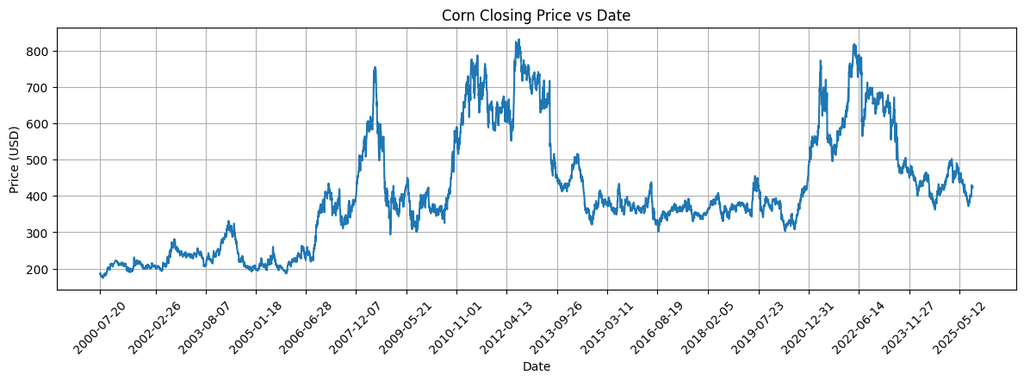

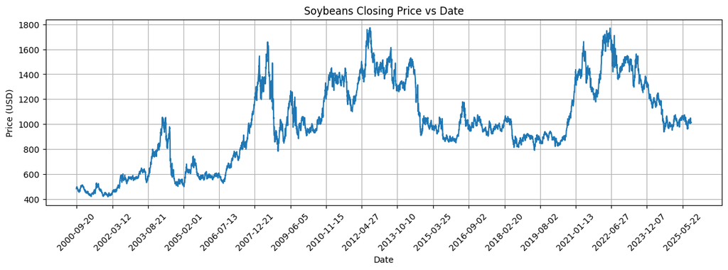

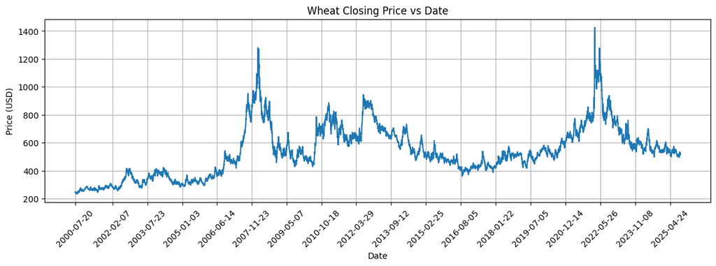

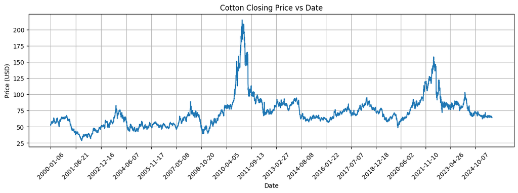

```python
for commodity, df in dfs.items():
    # Convert to pandas for plotting
    pdf = df.select(["Date", "Close"]).to_pandas()

    # Plot
    plt.figure(figsize=(12, 4))
    plt.plot(pdf["Date"], pdf["Close"], label=f"{commodity} Close", color='tab:blue')
    plt.title(f"{commodity} Closing Price vs Date")
    plt.xlabel("Date")
    plt.ylabel("Price (USD)")
    plt.grid(True)
    plt.tight_layout()
    plt.xticks(pdf["Date"][::365], rotation=45)  # every 365th date
    plt.show()
```

```python
for commodity, df in dfs.items():
    print(commodity)
    print(df['Target'].value_counts(normalize=True))
    print("-"*40)
```

```
Corn
shape: (2, 2)
┌────────┬────────────┐
│ Target ┆ proportion │
│ ---    ┆ ---        │
│ i32    ┆ f64        │
╞════════╪════════════╡
│ 1      ┆ 0.486431   │
│ 0      ┆ 0.513569   │
└────────┴────────────┘
----------------------------------------
Soybeans
shape: (2, 2)
┌────────┬────────────┐
│ Target ┆ proportion │
│ ---    ┆ ---        │
│ i32    ┆ f64        │
╞════════╪════════════╡
│ 1      ┆ 0.51454    │
│ 0      ┆ 0.48546    │
└────────┴────────────┘
----------------------------------------
Wheat
shape: (2, 2)
┌────────┬────────────┐
│ Target ┆ proportion │
│ ---    ┆ ---        │
│ i32    ┆ f64        │
╞════════╪════════════╡
│ 1      ┆ 0.476952   │
│ 0      ┆ 0.523048   │
└────────┴────────────┘
----------------------------------------
Cotton
shape: (2, 2)
┌────────┬────────────┐
│ Target ┆ proportion │
│ ---    ┆ ---        │
│ i32    ┆ f64        │
╞════════╪════════════╡
│ 0      ┆ 0.505038   │
│ 1      ┆ 0.494962   │
└────────┴────────────┘
----------------------------------------
```

### References:

This code was referenced from 451 Financial Engineering: Programming Assignment 1 jump start code provided by Thomas W. Miller, June 18, 2025